### Learning Objectives

> - Use R to practice loading, manipulating, and visualizing growth rate data.
> - Implement growth rate models in R.
> - Examine more complex growth data to challenge model assumptions.

## Loading some growth rate data

As always, you can download a script with nothing but the R code here.

In this lesson we’ll load some real experimental growth rate data into R. In some cases we might start with data stored locally on our computer, or online via a link. But here we’ll take advantage of a data set that is built into an R package called *growthrates*. Unless you’ve been doing some growth rate modeling on your own already, you probably don’t have this package installed yet. In RStudio, install it with the install.packages() function, calling install.packages(“growthrates”). Now let’s load it into our R session with library().

```r
library(growthrates)
```

#### Advanced note – checking for installed packages

*If you were writing a script that needed the user to load a certain package, it is better to check if they’ve installed, then load or install+load as necessary. Here’s an example piece of code that does it. Don’t stress if this feels too advanced.*

```r
if(!require(growthrates)) install.packages("growthrates",repos = "http://cran.us.r-project.org")
```

## Getting to know the new package and data

Okay, so we’ve loaded the package. Let’s look at the help file.

```r
?growthrates
```

After you run that code, you see that this package has several functions to fit models to experimental growth rate data. From the examples at the bottom it looks like they’ve included some data sets. They work with the data *bactgrowth* in this example. If you want to know what data are included in a package, the data() function can help you.

```r
data(package = "growthrates")
```

So we can see that there are two datasets: *bactgrowth* and *antibiotic*. It turns out that *bactgrowth* is an extremely messy dataset that the package authors included to show how their model-fitting works on tricky data. *antibiotic* is a bit easier to interpret. Let’s use the ? function to see what these data are.

```r
?antibiotic
```

```
## starting httpd help server ... done
```

We can see that these data are growth rates for the bacterium [Pseudomonas putida](https://en.wikipedia.org/wiki/Pseudomonas_putida), grown at different concentrations of the antibiotic tetracycline. This is an interesting bacterium; it may prove useful for clearing polluted soils of some byproducts of petroleum refining. Even though we’ve loaded the package *growthrates*, we still need to load the data. Here the data() function comes into play again.

```r
data(antibiotic)
```

#### Advanced note – the diverse outputs of a single function.

*You may be surprised that the data() function could yield a list of data, or load a particular data set, depending on the arguments you enter. Many functions in R can take a range of arguments, and the output many depend on what arguments you chose to specify. The help function ? (here you’d use ?data) is useful for exploring everything that a function can do.*

Let’s get back to the data. After running data(antibiotic) you can see in the upper right of RStudio that we have a new object in our globl environment. Now we must figure out how it is organized. There are several functions that summarize a data set for easy reading. One particularly useful one is str().

```r
str(antibiotic)
```

```
## 'data.frame':    2928 obs. of  5 variables:
##  $ time    : num  0 0.5 1 1.5 2 2.5 3 3.5 4 4.5 ...
##  $ variable: Factor w/ 48 levels "R_R3_0","R_R3_0.002",..: 1 1 1 1 1 1 1 1 1 1 ...
##  $ value   : num  0.00881 0.00981 0.01281 0.01781 0.02281 ...
##  $ conc    : num  0 0 0 0 0 0 0 0 0 0 ...
##  $ repl    : Factor w/ 4 levels "R3","R4","R5",..: 1 1 1 1 1 1 1 1 1 1 ...
```

What is this summary telling us? A lot! We see that there are 2928 observations (rows) in our data, and each observation has 5 variables (columns). *time* and *value* are our key variables here. *time* tells us the time in hours from the beginning of each experiment, and *value* tells us the bacterial concentration at that time point in that well. This is all measured using optical density in a plate reader – there are many separate wells of media and bacteria that are all growing in parallel. By measuring the optical density (absorbance) of the fluid to light, you can estimate the bacterial population size. In this case they didn’t use a reference to translate these numbers back to a population size, but the relative change should still be useful for seeing the pattern of growth. (Note: this assumes that the optical density changes linearly with the bacterial concentration.)

There are a few other variables *conc* tells us the concentration of tetracylcine used in each well, and *repl* tells use which replicate. They had four replicates. In other words, they repeated each growth experiment with the exact same antibiotic concentration 4 times. This helps check that they are getting consistent results.

#### Thought question – sources of noise

> *Based on the results from a single lab, would you be confident to drawing conlusions about these bacteria in general? What are some other sources of noise that might influence the growth rate data?*

## Visualizing our data

These data are already pretty tidy and well-organized for plotting. We’ll use the *ggplot2* package to make plots. It’s easy to work with, flexible, and can quickly make high quality data visualizations. Let’s load it and get started. Instead of explaining everything, you can try to fiddle with the code to start getting a feel for the syntax. You’ll probably need to install the package *ggplot2*, unless you’ve already used it before.

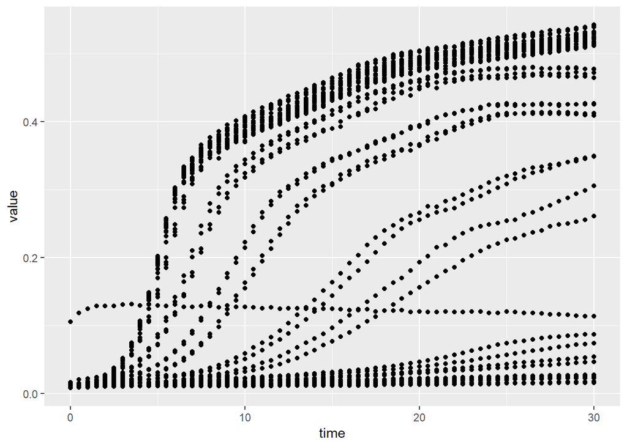

```r
library(ggplot2)
ggplot(antibiotic,aes(x=time,y=value))+geom_point()
```

With one short line of code, we made a pretty nice plot. A few notes about what I entered into the ggplot() function. I first entered the data frame (our matrix, antibiotic). Then I entered the *aesthetics* using `aes()`, specifying that the x-axis  
represents variable *time* and the y-axis represents *value*. These names need to exactly match the variable names from our data frame.

So, it looks okay, but we’ve obscured the information about antibiotic concentration. We can also specify color using `aes()`. Let’s represent the concentrations using different colors.

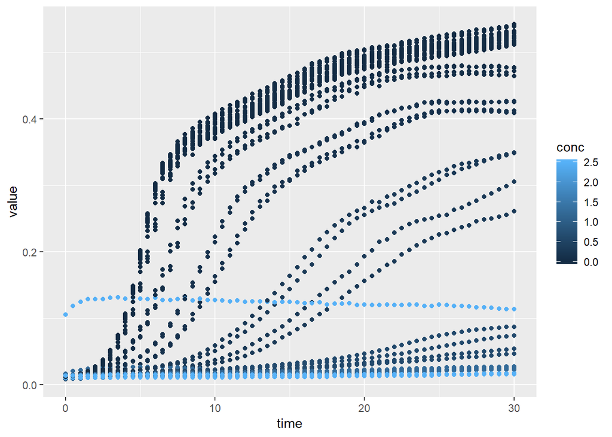

```r
ggplot(antibiotic,aes(x=time,y=value,color=conc))+geom_point()
```

Hmmm, that doesn’t look great. We could dive into the nitty gritty of specifying custom color scales. The automatic scale doesn’t work well when some values are very close together while others are spread apart. We could transform the data. Or we could use a little hack – it turns out that `ggplot()` works better in these cases when the variable is a discrete (or factor) scale, not a continuous scale. Don’t stress if this feels confusing, but let’s just try turning the concentrations into a discrete factor variable instead.

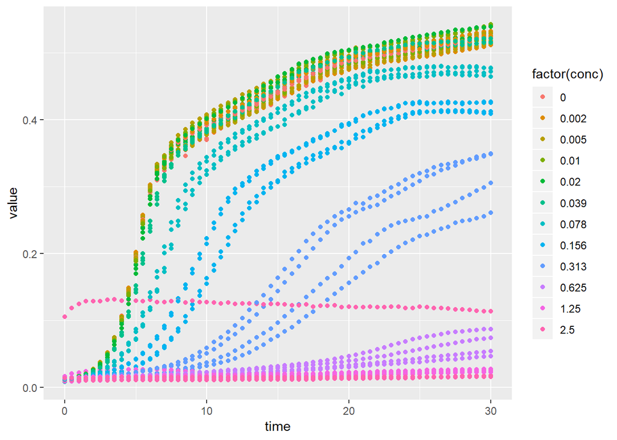

```r
ggplot(antibiotic,aes(x=time,y=value,color=factor(conc)))+geom_point()
```

That’s a bit easier to read. Now we can clearly see the different replicates within a single concentration, and we can distinguish pretty well between the concentration gradients.

#### Thought question – interpreting the data

> Let’s practice interpreting these graphs. What is the plot above showing us?  
> How is concentration affecting growth rates? Are there any outliers? Is this growth linear? Exponential? How would you describe it?

Page built on: 2018-09-06 at 12:01:29